# DS5220 Project 1

##### 3. Using your R code for 3.3.1.1, map a continuous variable to `color`, `size`, and `shape`. How does the aesthetic `shape` behave differently for mappings to `fl` and `displ`?

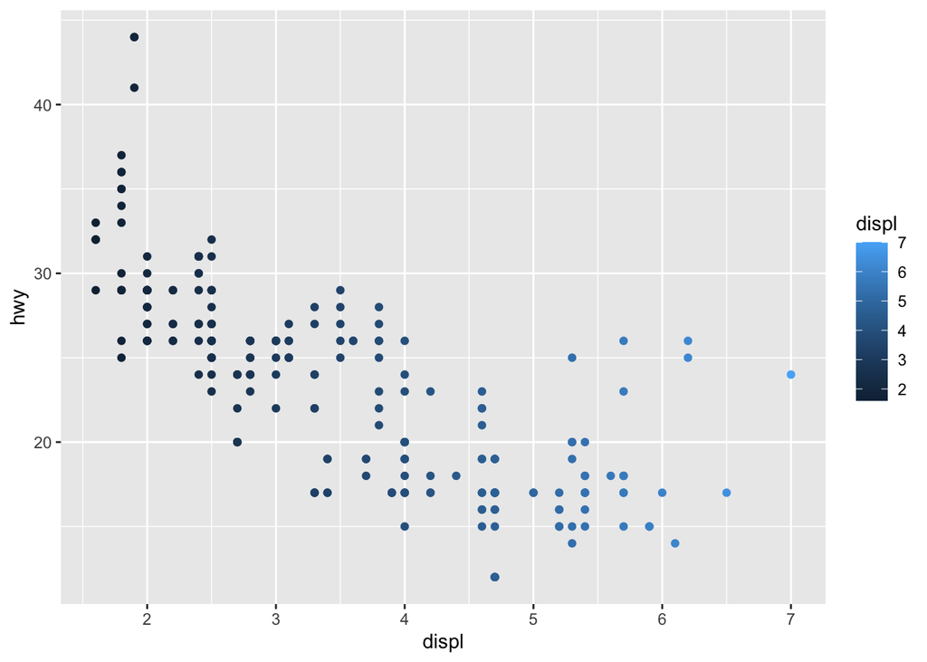

```r
# For color
ggplot(data = mpg) +
  geom_point(mapping = aes(x = displ, y = hwy, color=displ))
```

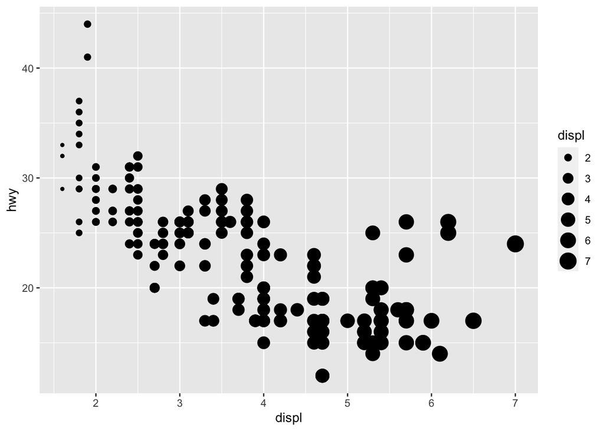

```r
# For Size
ggplot(data = mpg) +
  geom_point(mapping = aes(x = displ, y = hwy, size=displ))
```

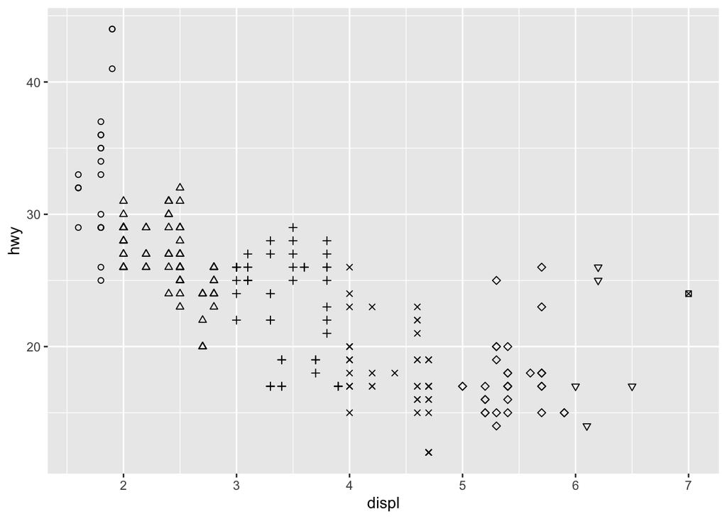

```r
# For Shape
# here we use the shape parameter for geom_point()
# This is not throwing error but it is useless because we don't have legends.
# geom_point here has taken the continous variable and scaled it to integer values of the shapes.
ggplot(data = mpg) +
   geom_point(mapping = aes(x = displ, y = hwy), shape=mpg$displ, show.legend = TRUE)
```

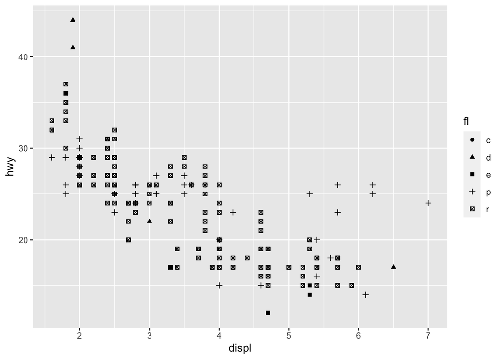

```r
ggplot(data = mpg) +
  geom_point(mapping = aes(x = displ, y = hwy, shape=fl))
```

```r
# ggplot(data = mpg) +
#   geom_point(mapping = aes(x = displ, y = hwy, shape=mpg$displ), )

# AES() does not have auto scale. Shapes cannot be continous as shapes dont have magnitude. While Color and Size have a magnitude which is continous.
# Caused by error in `scale_f()`:
# ! A continuous variable cannot be mapped to the shape aesthetic
# ℹ choose a different aesthetic or use `scale_shape_binned()`
```

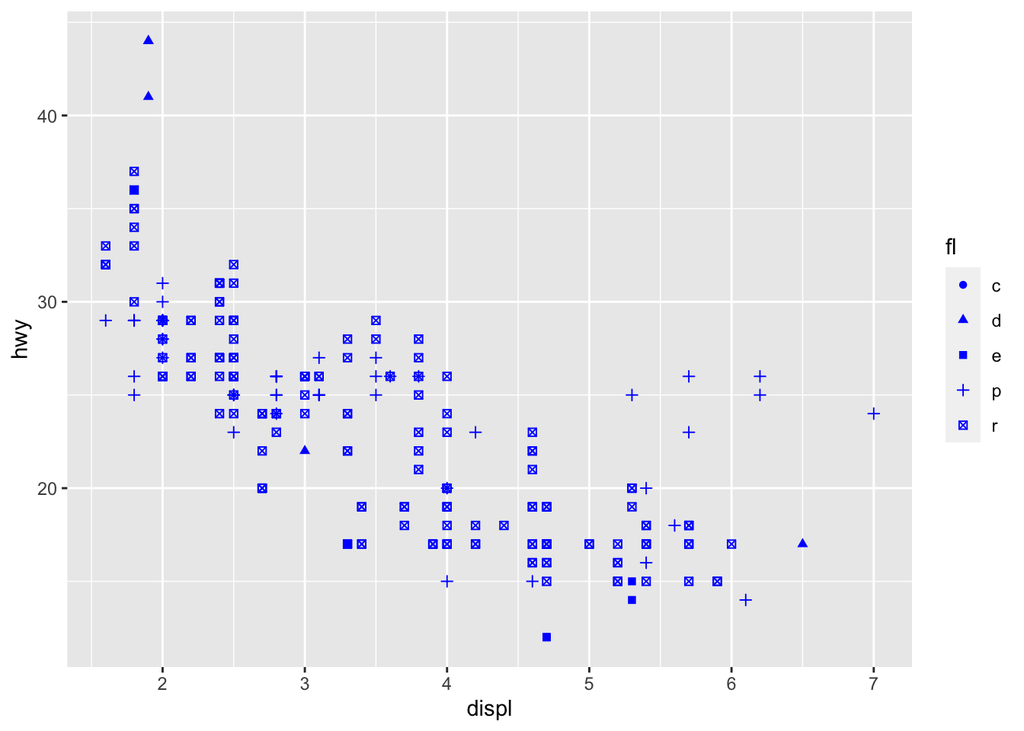

```r
ggplot(data = mpg) +
  geom_point(mapping = aes(x = displ, y = hwy, shape=fl), color="blue")
```

##### 4. What happens if you map the same variable to multiple aesthetics? Use an example from your answers to problem 3.3.1.3.

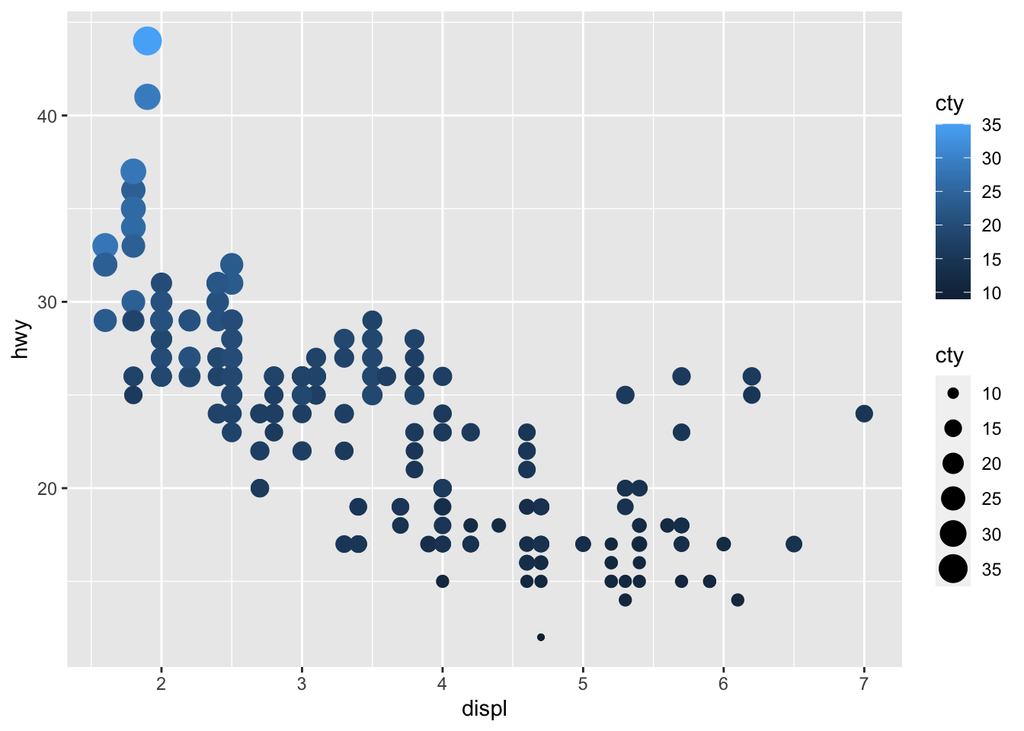

```r
ggplot(data = mpg) + geom_point(aes(x = displ, y = hwy, color = cty, size = cty))
```

```r
# Multi aesthetics adds multiple dimensions to the plot
```

##### 5. What does the `stroke` aesthetic do? What shapes does it work with? (Hint: use`?geom_point`) Try it with `shape=21` and `stroke=displ` in your code from 3.3.1.1.

The `stroke` parameter is an aesthetic in `geom_point` which sets the thickness of the point’s border. `stroke` seems to be working with most of the shapes.

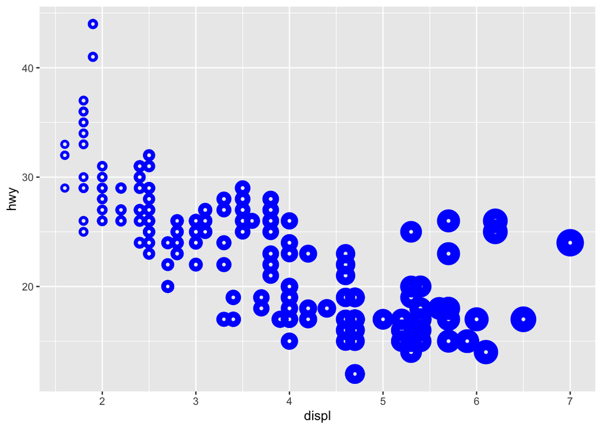

```r
ggplot(data = mpg) +
  geom_point(mapping = aes(x = displ, y = hwy), color="blue", shape=21, stroke=mpg$displ)
```

##### 6.What happens if you map an aesthetic to something other than a variable name, like `aes(colour = displ < 5)`? Try this by modifying your code in problem 3.3.1.1.

This is using the result of `displ<5` calculation and using that as aesthetics

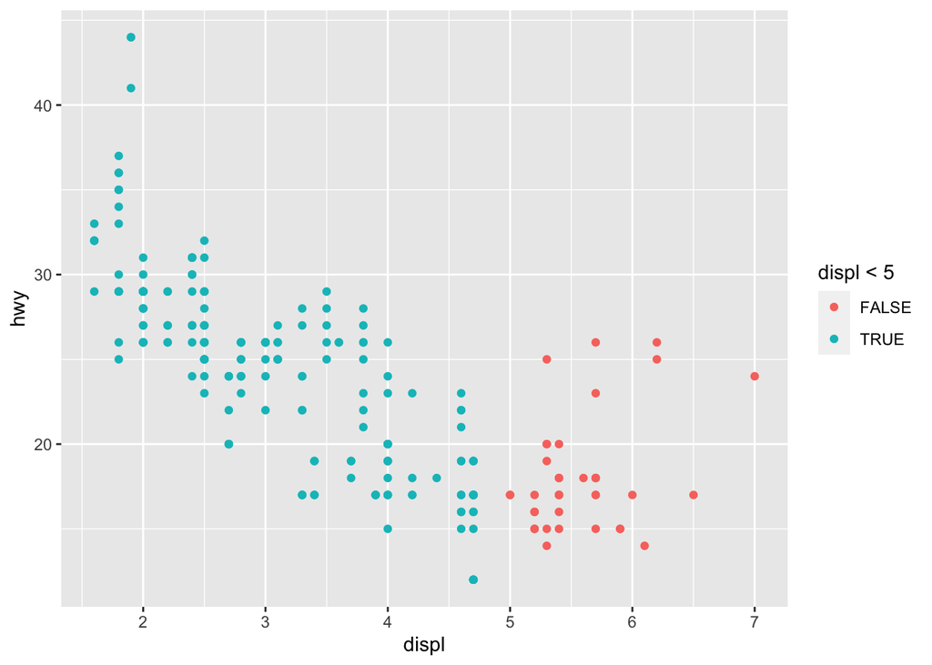

```r
ggplot(data = mpg) +
  geom_point(mapping = aes(x = displ, y = hwy, color=displ<5))
```